# Comptes de branche. Résultats détaillés des grands indicateurs macroéconomique des Comptes Nationaux Trimestriels.

@statjunior

mai 31, 2023

# 1 Présentation

Ce rapport *RMarkdown* présente les résultats détaillés des comptes de branche. Il présente les grands agrégats économiques de la production (PIB) et des revenus de la nation (Excédent Brut d’exploitation, Salaire Moyen par Tête).

Dans un premier temps, on s’intéresse à la croissance trimestrielle du PIB. On constate les contributions à l’évolution du PIB par grande fonction (Consommation, Investissement, Solde extérieur, Variations de stocks). On compare le PIB en variation trimestrielle et en évolution depuis la Crise du Covid.

On présente également l’évolution du solde extérieur de la France (exports - imports).

Un focus est présenté sur l’évolution de la consommation des ménages depuis le Covid, en particulier pour la consommation alimentaire et énergétique.

On se penche ensuite sur la conjoncture économique des secteurs d’activité de l’économie française. On présente les gains (ou les pertes) de valeur ajoutée par branche depuis le Covid.

Une attention particulière est portée à l’évolution de la productivité du travail depuis la crise du Covid. En lien avec la productivité du travail, on constate l’évolution du Salaire Moyen par Tête.

Le rapport se conclut enfin par un développement détaillé des marges sectorielles des entreprises. Une attention particulière est portée aux secteurs énergétiques dont les profits ont considérablement augmenté depuis 2021.

## 1.1 Croissance du PIB

### 1.1.1 Décomposition de la croissance du PIB trimestrielle par l’approche demande (Conso+Investissement+(Export-Import)+Variations de Stocks)

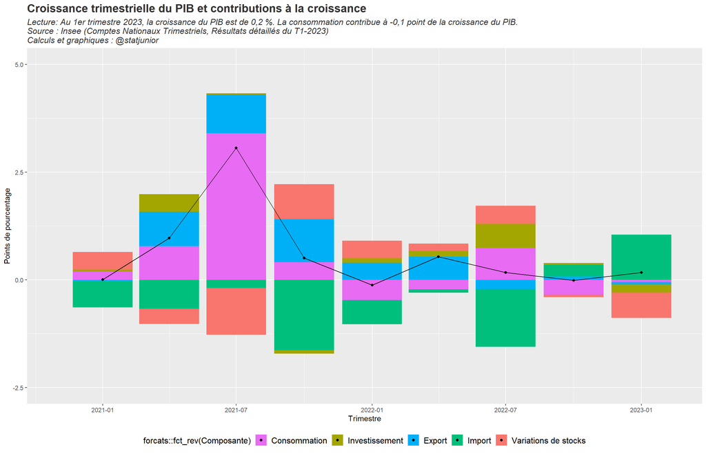

## 1.2 Evolution des composantes du PIB en volume par rapport au T4-2019

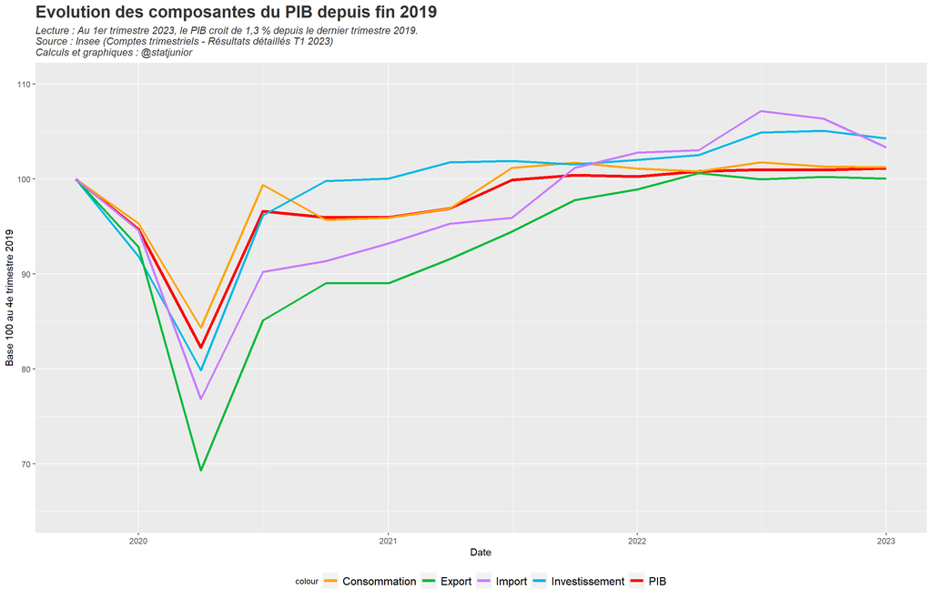

## 1.3 Glissement des déflateurs des composantes du PIB au dernier trimestre connu

[figure not shown]

## 1.4 Niveau des déflateurs par rapport au T4-2019

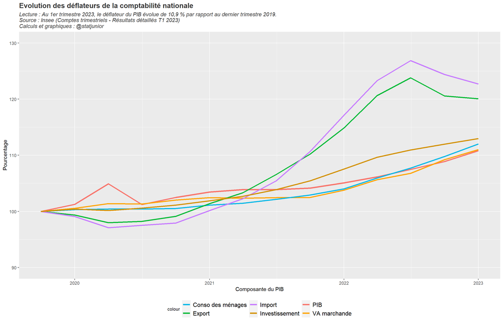

# 2 Solde des échanges extérieurs de la France

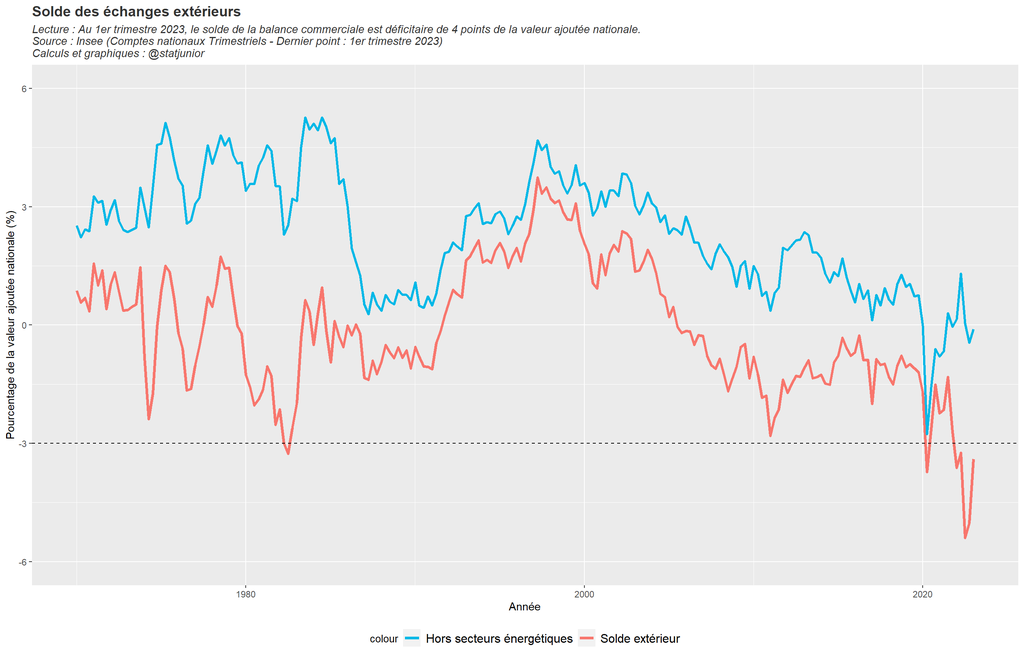

# 3 Consommation

## 3.1 Consommation énergétique et agro-alimentaire en volume depuis fin 2019

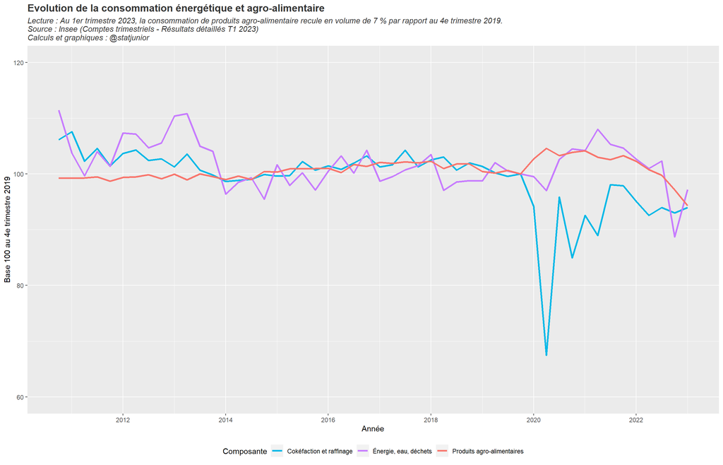

## 3.2 Evolution sur longue période de la consommation alimentaire en volume

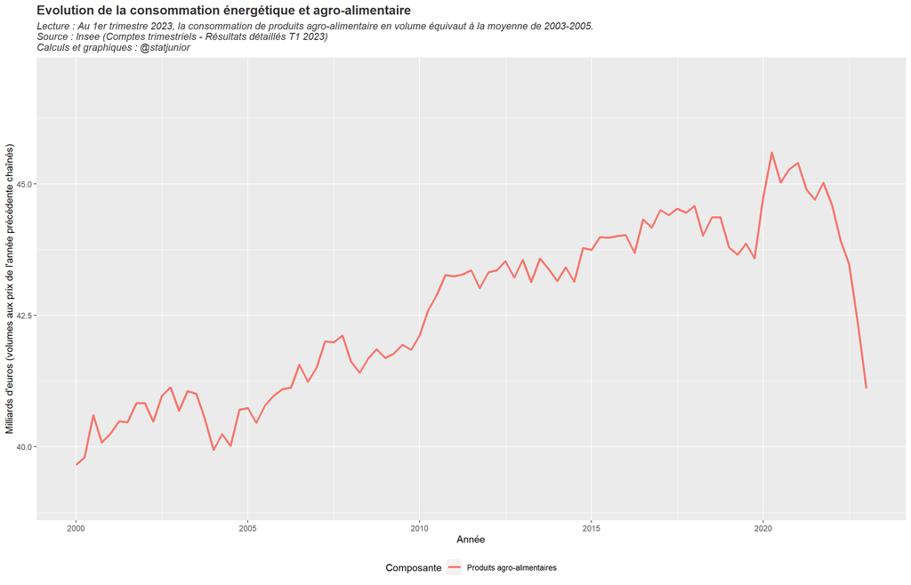

# 4 Salaires, Masse salariale et Productivité du travail

## 4.1 Evolution de la valeur ajoutée et de la productivité du travail depuis 2000

[figure not shown]

## 4.2 Evolution de la producitivté du travail et du Salaire Moyen par Tête (SMPT) depuis 2000

[figure not shown]

## 4.3 Evolution de la valeur ajoutée et de la productivité du travail depuis 2019

[figure not shown]

[figure not shown]

[figure not shown]

## 4.6 Volume de travail global et productivité du travail depuis 1990

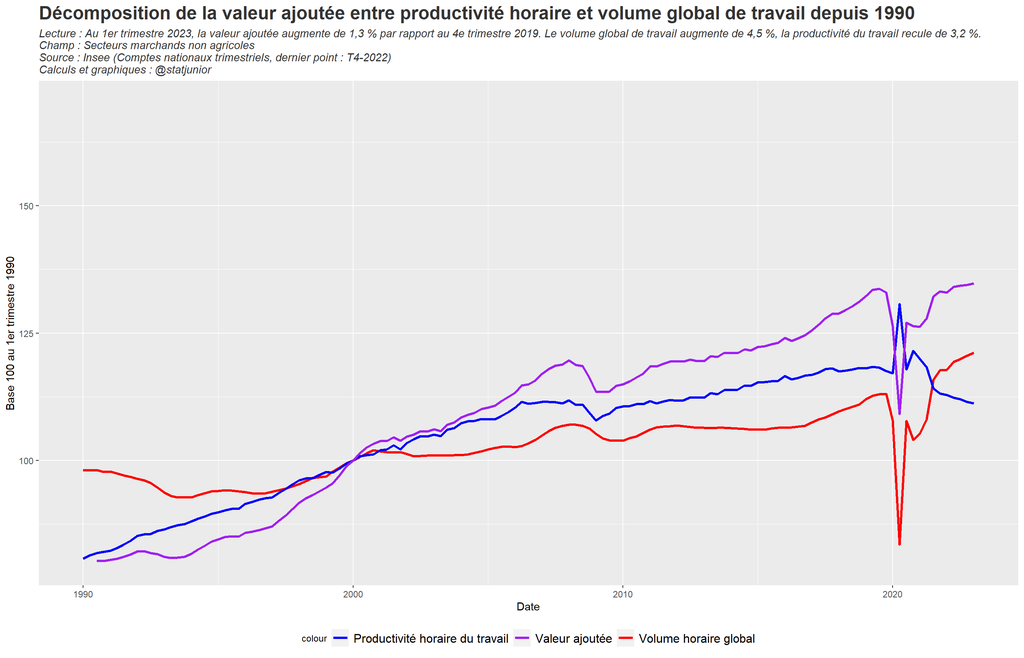

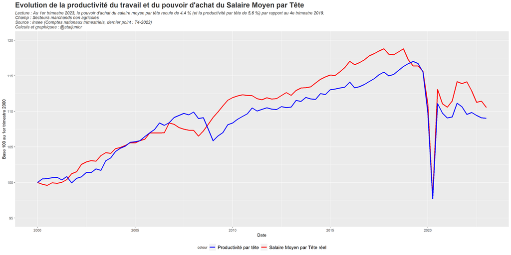

# 5 Décomposition des agrégats macoréconomiques par branche d’activité

## 5.1 Valeur ajoutée par branche depuis fin 2019

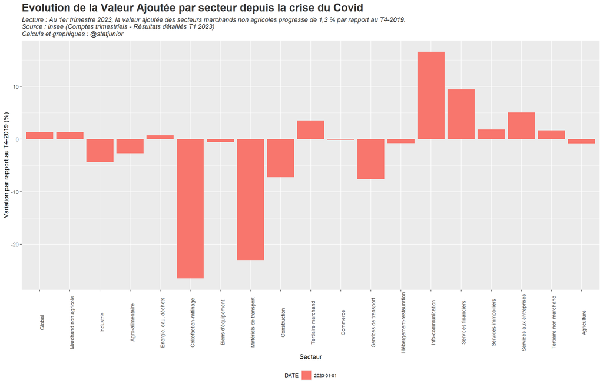

## 5.2 Productivité du travail sectorielle depuis 2019

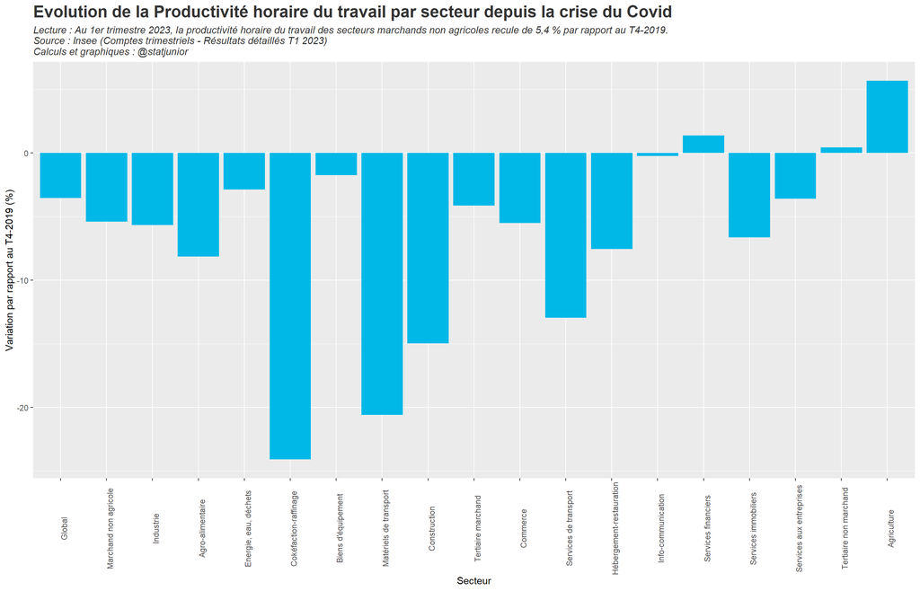

## 5.3 Evolution du volume d’heures travaillées par branche depuis 2019

[figure not shown]

## 5.4 Décomposition de la Productivité : contribution de la valeur ajoutée et du volume d’heures travaillées par secteur

[figure not shown]

# 6 Taux de marge

## 6.1 Evolution du taux de marge sur longue période

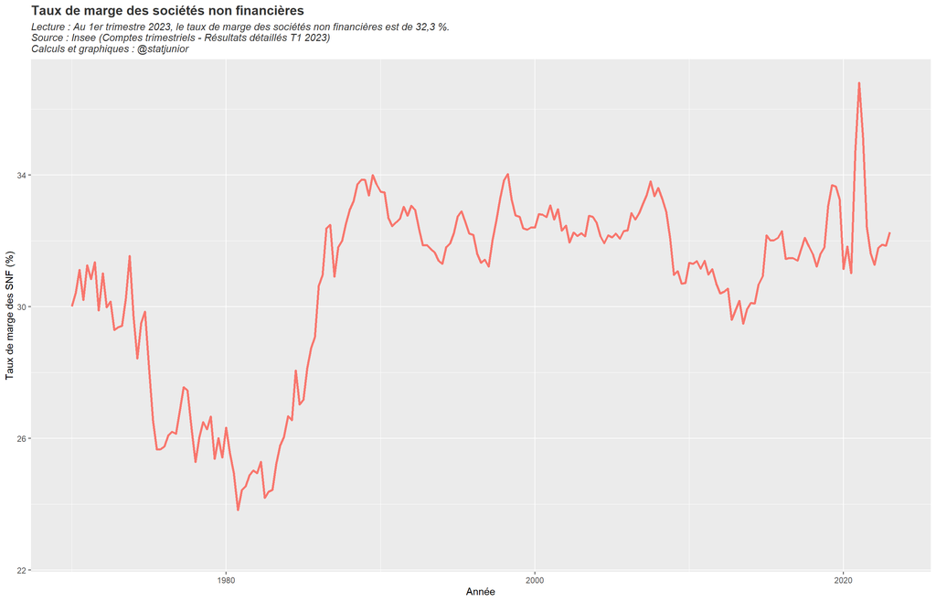

## 6.2 Décomposition du taux de marge par contribution (productivité, masse salariale, cotisations sociales, termes de l’échange, autres facteurs)

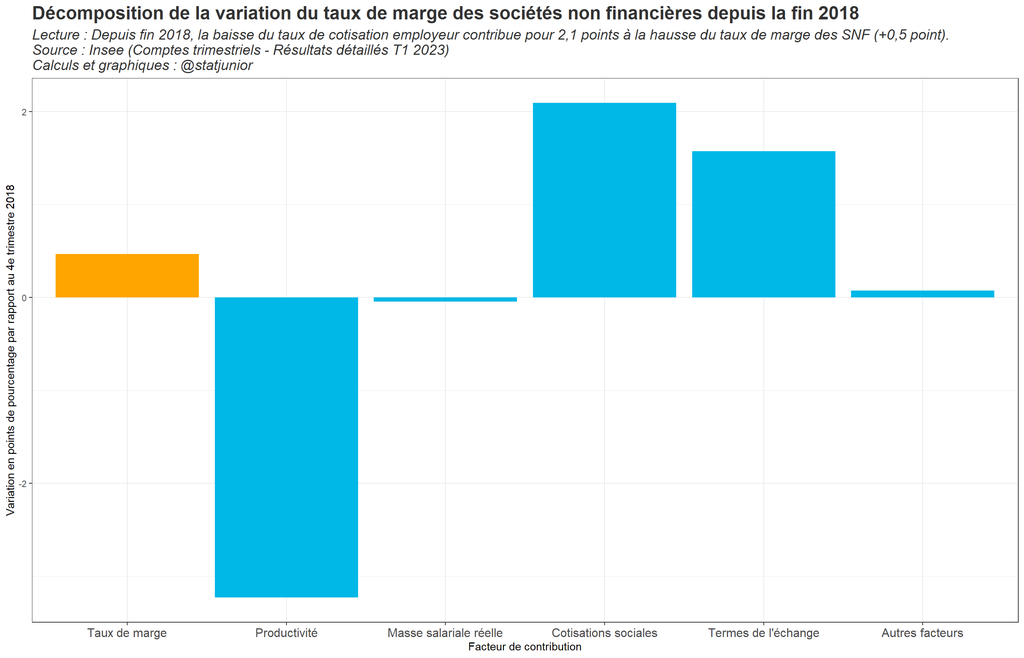

## 6.3 Evolution du taux de marge par secteur par rapport à l’année 2018

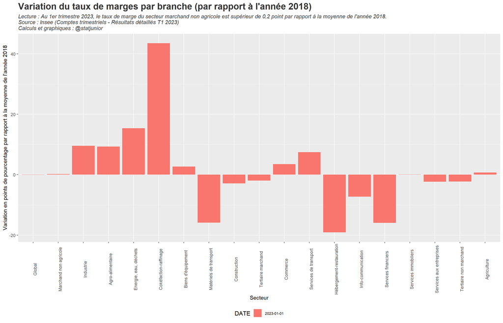

# 7 Profits exceptionnels liés aux tensions inflationnistes depuis 2021

## 7.1 Taux de marge des secteurs énergétiques et des services de transport

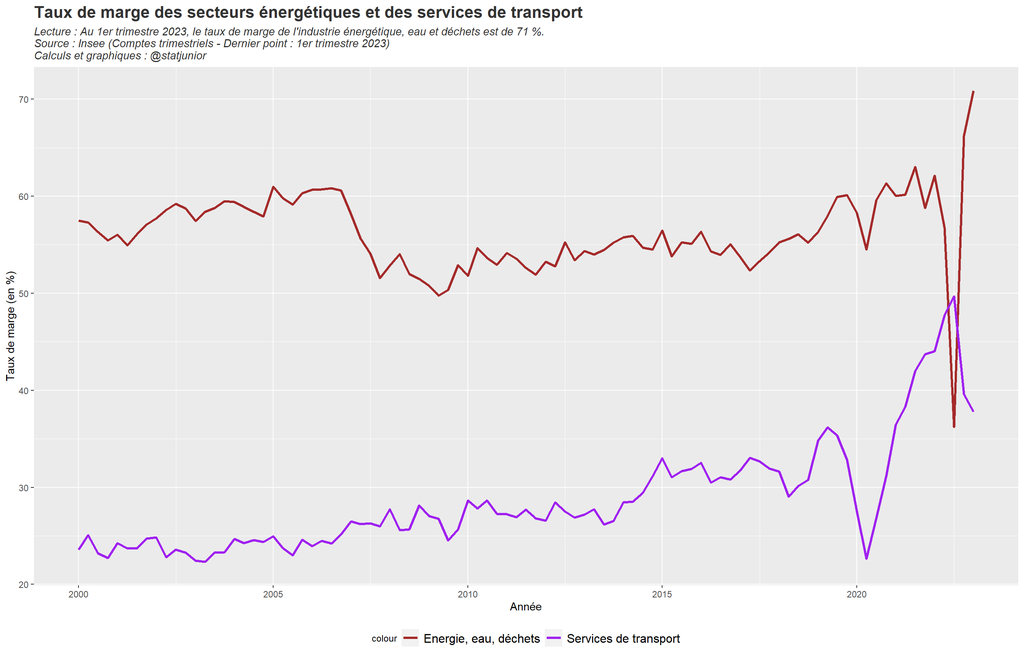

## 7.2 EBE rapporté à la production des secteurs énergétiques, de l’agroalimentaire et des services de transport

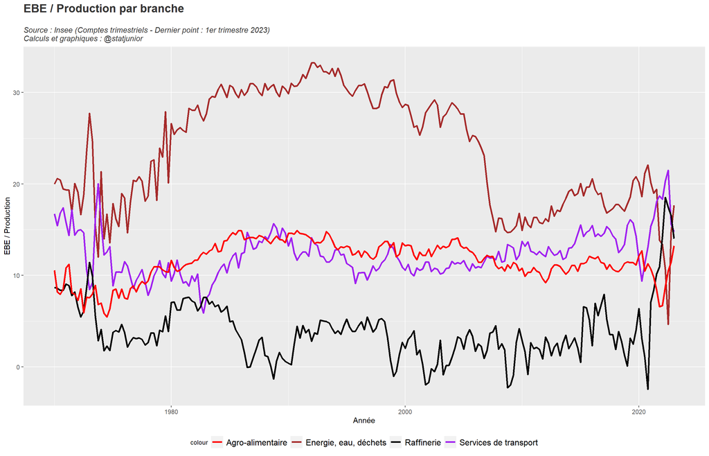

## 7.3 Taux de marge de l’industrie cockéfaction - raffinage

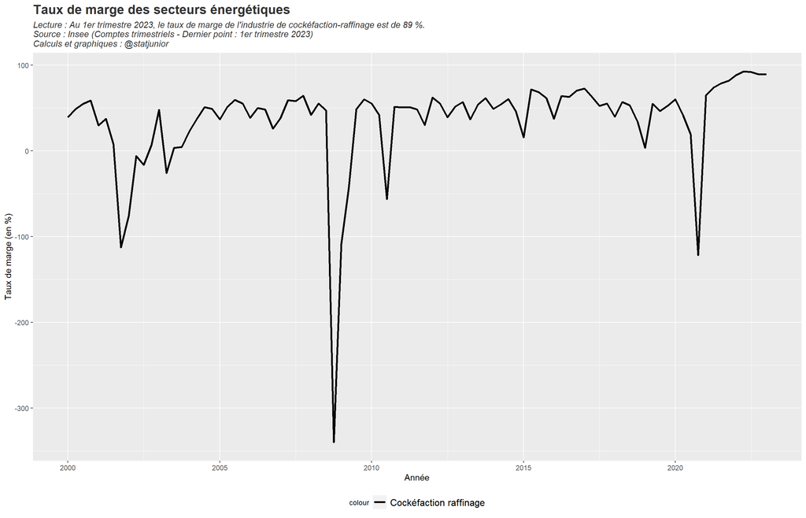

## 7.4 Taux de marge de l’industrie agro-alimentaire

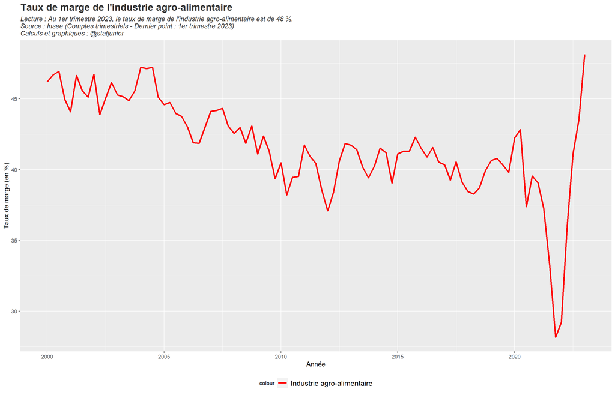

## 7.5 Part des profits exceptionnels des secteurs énergétiques dans l’ensemble de la valeur ajoutée française

[figure not shown]

## 7.6 Part des profits exceptionnels des secteurs énergétiques et de l’industrie agro-alimentaire dans l’économie française

[figure not shown]